# R Crash Course for Molecular Medicine

Lecture 3: reading and writing files

January Weiner

Core Unit for Bioinformatics, BIH@Charité

Andranik Ivanov

Core Unit for Bioinformatics, BIH@Charité

## Aims for today

- Reading data
- Basic statistics
- Cleaning data
- (Regular expressions)
- Searching, sorting and selecting

## Repetitorium of Day 2

# Reading and writing data

## Exercise 3.0: Where is my file?

(no room splitting for this exercise)

- download the file [labres_selected_simple.xlsx](https://github.com/bihealth/MolMed-RCourse/blob/b154a1b9b96266e935058d74943aa128b172f4df/Datasets/labres_selected_simple.xlsx?raw=true) and save it in your working directory.
- open your R session. Run: `list.files()`. Can you see the file you just downloaded?
- If not, check your working directory with `getwd()`. Is this the same directory that you have downloaded the file to?
- Open the file with Excel or LibreOffice and look at its contents.
- Now read the file into R with the `readxl` package (`install.packages("readxl")` if you don’t have it yet). Use the function `read_excel()` and assign the result to a variable called `labres`.

## Where are your files - absolute vs relative paths

(remember, “directory” is just an older word for “folder”)

- absolute path start at root directory, e.g.  
  `C:/Users/foobar/CUBI/teaching/202403_RCrashCourse/lecture01.R`
- Note the slash (`/`) instead of backslash (`\`).
- Where am I? - `getwd()`
- relative paths start at working directory, e.g. `Datasets/iris.csv`
- Downloading files from our git-repository

## IMPORTANT!

**Never use absolute paths!**

Absolute paths are system-dependent and will break your code when you move to another location, another computer or share your code with others.

(Exeptions apply, but only very rarely - e.g. when working with system files or HPC files installed for all users)

## Using Rstudio to import data sets

**Rstudio generates R code**

If you use Rstudio to import a dataset, it will generate the R code for you. You can copy this code into your script and use it to read the data in the future. Note that the paths generated by Rstudio are absolute paths, so you will have to change them to relative paths.

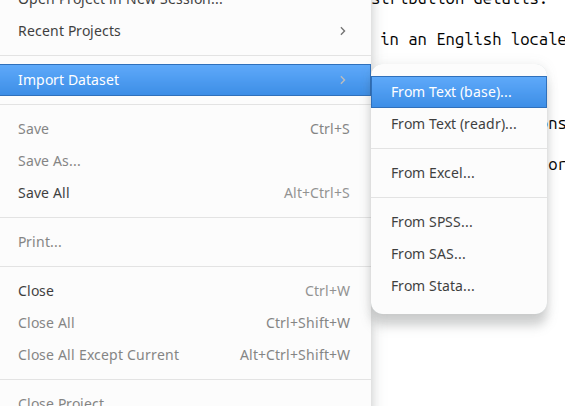

Rstudio import dataset

## Just a quick detour: effects of vaccination

The labres file you have downloaded and read contains some data on the effects of influenza vaccination on day 1 after the vaccination. The columns “CRP”, “NEUT” and “ALB” contain the C-reactive protein and neutrophil counts, respectively, for either placebo or vaccinated individuals.

Weiner, January, et al. “Characterization of potential biomarkers of reactogenicity of licensed antiviral vaccines: randomized controlled clinical trials conducted by the BIOVACSAFE consortium.” Scientific Reports 9.1 (2019): 20362.

## What can we do with the data: histograms, boxplots, t-test

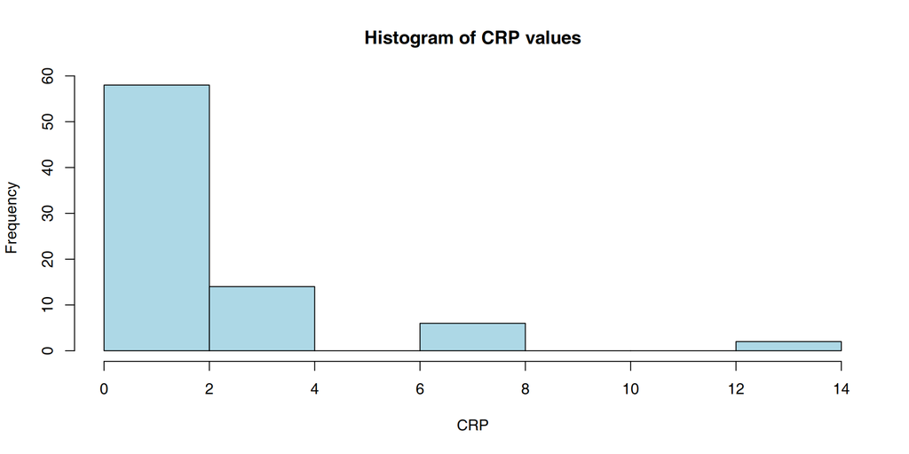

```r
# make a histogram
hist(labres$CRP, main="Histogram of CRP values",
     xlab="CRP", col="lightblue")
```

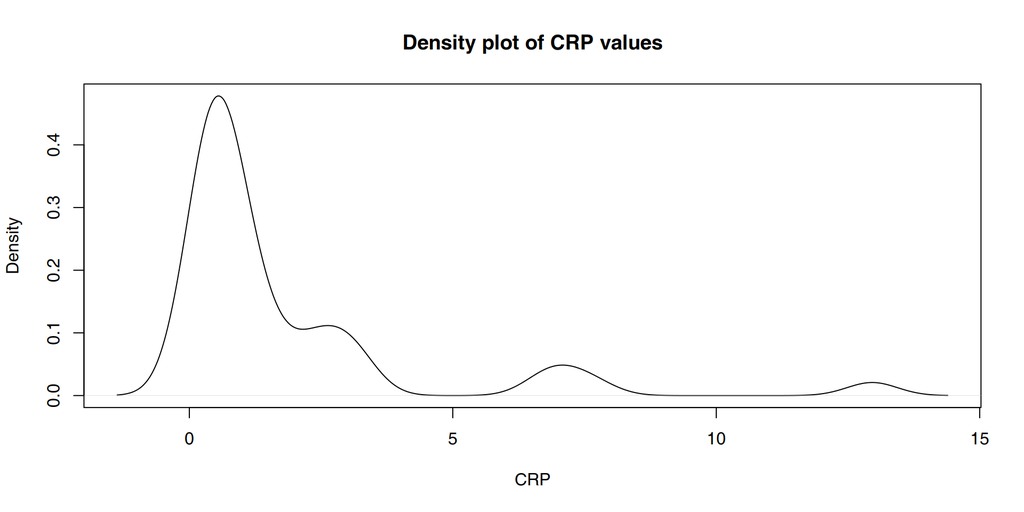

```r
# make a density plot
density <- density(labres$CRP)
plot(density, main="Density plot of CRP values",
     xlab="CRP")
```

## What can we do with the data: histograms, boxplots, t-test

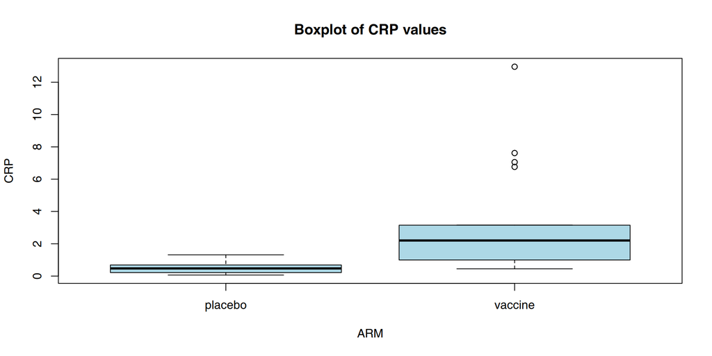

```r
# make a boxplot
boxplot(CRP ~ ARM, data=labres, main="Boxplot of CRP values", ylab="CRP", col="lightblue")
```

Box plots (box and whisker plots) are usually better for comparing two groups than bar plots. Actually, you should avoid bar plots in most cases.

See the “[Kick the bar chart habit](https://www.nature.com/articles/nmeth.2837)” Nature Methods article.

## A t-test

```r
t.test(CRP ~ ARM, data=labres)
```

```
    Welch Two Sample t-test

data:  CRP by ARM
t = -5.1429, df = 39.726, p-value = 7.626e-06
alternative hypothesis: true difference in means between group placebo and group vaccine is not equal to 0
95 percent confidence interval:
 -3.581416 -1.560345
sample estimates:
mean in group placebo mean in group vaccine
            0.5020493             3.0729295
```

**t-test returns a list**

t-test returns a list with many elements. You can access them with the `$` operator, e.g. `t.test(CRP ~ ARM, data=labres)$p.value` will return the p-value of the test.

```r
res <- t.test(CRP ~ ARM, data=labres)
res$p.value
```

```
[1] 7.626023e-06
```

```r
names(res)
```

```
 [1] "statistic"   "parameter"   "p.value"     "conf.int"    "estimate"    "null.value"  "stderr"      "alternative" "method"      "data.name"
```

## Is the t-test suitable for this data?

**Wilcoxon is a good alternative**

Wilcoxon test is a non-parametric alternative to the t-test. It does not assume normality of the data and is more robust to outliers. You can use it with the `wilcox.test()` function in R.

The power of the Wilcoxon test is almost as good as the t-test, so you can use it in most cases. The only disadvantage is that it does not return a confidence interval for the difference between the two groups.

## Exercise 3.1: basic statistics

- Calculate the mean, median, standard deviation and interquartile range of the CRP values (functions `mean()`, `median()`, `sd()`, `IQR()`). Report the values.
- Can you think of a way to calculate these values for the two groups (placebo and vaccinated) separately? (think: logical vectors…)
- Use the `t.test()` or `wilcox.test()` function to test whether there is a significant difference in NEUT and ALB values between the two groups. Report the p-value.
- What other things do these tests return? (hint: asign the return value to a variable like `res` and use the `$` operator to access the elements of the list returned by the test)
- Make a histogram (`hist()`) and boxplot (`boxplot(y ~ x, data = foo)`) for the NEUT and ALB values. Do you see any differences between the two groups?

# Reading data: now for real

## Reading data

Main data types you will encounter:

| Data type | Function | Package | Notes |
| --- | --- | --- | --- |
| Columns separated by spaces | `read_table()` | `readr`/`tidyverse` | one or more spaces separate each column |
| TSV / TAB separated values | `read_tsv()` | `readr`/`tidyverse` | Delimiter is tab (`\t`). |
| CSV / comma separated | `read_csv()` | `readr`/`tidyverse` | Comma separated values |
| Any delimiter | `read_delim()` | `readr`/`tidyverse` | Customizable |
| XLS (old Excel) | `read_xls()` `read_excel()` | `readxl` | Just don’t use it. From the `readxl` package. |
| XLSX (new Excel) | `read_xlsx()` `read_excel()` | `readxl` | From the `readxl` package. You need to provide the sheet number you wish to read. Note: returns a tibble, not a data frame! |

## Base reading functions

**read.table, read.csv, read.tsv**

there are also “base R” functions `read.table`, `read.csv`, `read.tsv` (there is no function for reading XLS[X] files in base R). They are always available, but use them only in a pinch. The tidyverse functions above are preferable.

## Reading data: summary

- For reading text files (csv, tsv etc.), use the `readr` package. This package is loaded automatically when you load the `tidyverse` package: `library(tidyverse)`. Then, use the functions `read_csv`, `read_tsv` etc.
- For reading Excel files, use the `readxl` package: `library(readxl)`. Then, use the function `read_excel`.

# Cleaning data

## A short note on organizing your data

- If possible, use a specialized tool and not Excel (a database, specialized clinical data management system, REDCap etc.)

## And if you use Excel…

If you use Excel, follow these rules:

- NEVER modify original files
- Versionize your files
- Check data for consistency (e.g. with R!)
- Use preselected values
- Add a meta-data sheet describing the fields
- do not color-code or format-code your information (e.g. denoting treatment in bold)
- Add comments in separate fields
- NEVER throw away or replace any identifiers, always keep the old identifiers
- understand what you describe (patients? samples? assays?)
- understand the difference between wide and long format

## And if you use Excel and don’t follow these rules

- brace yourself for bad times

## Standardising column names

Column names should be uniform.

- They should not contain other characters than alphanumeric and underscore
- Dots are allowed, but not recommended (“old style”)
- They should not contain spaces.
- They should start with a letter

You can use the janitor package to clean up column names:

```r
library(janitor)
data <- read_csv("data.csv")
data <- clean_names(data)
```

## Diagnosing problems

Potential problems:

- incorrect import (e.g. numeric values as strings)
- typos (e.g. “x15” instead of “15”)
- incongruent labels (e.g. mixing “M”, “male” and “männlich”)
- mixing upper and lower case
- mixing different types of decimal separator
- special numeric values (e.g. “> 10”, “< 5”)
- comments in the same column (“10 (unreliable)”)
- dates (also, Excel converts certain strings to dates)

## Diagnosing problems

```r
library(tidyverse)
myiris <- read_csv("../Datasets/iris.csv")
```

- Use `summary`, `class` and `typeof` functions to find potential problems. This is what we expect:

```r
typeof(myiris$Petal.Width)
```

```
[1] "double"
```

```r
class(myiris$Petal.Width)
```

```
[1] "numeric"
```

```r
summary(myiris$Petal.Width)
```

```
   Min. 1st Qu.  Median    Mean 3rd Qu.    Max.
  0.100   0.300   1.300   1.199   1.800   2.500
```

## Diagnosing problems

```r
typeof(myiris$Petal.Width)
class(myiris$Petal.Width)
summary(myiris$Petal.Width)
```

Longer explanation: `typeof` returns the so called “storage type”, that is the very basic type of a value (string, logical, integer, list etc.). `class` can be different (more specific). For example, if `mtx` is a matrix of numbers, `typeof(mtx)` is `double`, and `class(mtx)` is `matrix`.

## Diagnosing problems

- Use `summary`, `class` and `typeof` functions to find potential problems. This is **not** what we expect:

```r
 typeof(myiris$`Sepal Length`)
```

```
[1] "character"
```

```r
  class(myiris$`Sepal Length`)
```

```
[1] "character"
```

```r
summary(myiris$`Sepal Length`)
```

```
   Length  N.unique   N.blank Min.nchar Max.nchar
      150        37         0         1         5
```

(we use the back ticks because the column name contains a space)

## `table()` for overview

When used with one argument, `table` shows how many times each value occurs:

```r
table(myiris$Species)
```

```
    setosa     Setosa versicolor Versicolor  virginica  Virginica
        45          5         42          8         46          4
```

## `table()` for constructing contingency tables

When used with two arguments, `table` constructs a contingency table:

```r
library(readxl)
meta_data <- read_excel("../Datasets/meta_data_botched.xlsx")
table(meta_data$PLACEBO, meta_data$ARM)
```

```
         A agrippal Agrippal agrippal vaccine Agrippal vaccine AGRP. control  F Fl. Fluad FLUAD fluad vaccine Fluad vaccine Fuad grippal  P placebo Placebo Placibo
  0      1        0        0                0                0     0       0  1   1     0     0             0             0    0       0  0       0       0       0
  1      0        0        0                0                0     0       1  0   0     0     0             0             0    0       0  2       0       0       0
  F      1        0        0                2                0     0       0  1   2     0     1             1             0    0       0  0       0       0       0
  false  0        0        0                1                0     0       0  3   0     0     0             1             0    0       0  0       0       0       0
  FALSE 13        2        2                1                4     5       0 13   3     4     3             2             1    3       4  0       0       0       0
  no     5        0        0                0                1     0       0  0   0     0     0             0             0    0       0  0       0       0       0
  T      0        0        0                0                0     0       0  0   0     0     0             0             0    0       0  1       0       0       1
  true   0        0        0                0                0     0       1  0   0     0     0             0             0    0       0  4       0       0       0
  TRUE   0        0        0                0                0     0       4  0   0     0     0             0             0    0       0 13       1       2       6
  yes    0        0        0                0                0     0       0  0   0     0     0             0             0    0       0  0       1       0       0

        Plazebo
  0           0
  1           0
  F           0
  false       0
  FALSE       0
  no          0
  T           1
  true        0
  TRUE        1
  yes         1
```

This can tell us if there are any inconsistencies in the data.

## Diagnosing problems

- The colorDF package provides a function called `summary_colorDF` which can be used to diagnose problems with different flavors of data frames:

```r
library(colorDF)
summary_colorDF(myiris)
```

```
# Color data frame (class colorDF) 5 x 5:
 │Col         │Class│NAs  │unique│Summary
1│Sepal Length│<chr>│    0│    37│5: 10, 5.1: 9, 6.3: 9, 5.7: 8, 6.7: 8, 5.5: 7, 5.8: 7, 6.4: 7…
2│Sepal Width │<dbl>│    0│    25│ 2.00 [ 2.80 < 3.00>  3.38] 36.00
3│Petal?Length│<chr>│    0│    47│1.5: 13, 1.4: 12, 4.5: 8, 1.3: 7, 5.1: 7, 1.6: 6, 5.6: 6, 4: …
4│Petal.Width │<dbl>│    0│    22│0.1 [0.3 <1.3> 1.8] 2.5
5│Species     │<chr>│    0│     6│virginica: 46, setosa: 45, versicolor: 42, Versicolor: 8, Set…
```

## Diagnosing problems

Another useful package is `skimr`, which provides a function `skim` which provides a summary of each column:

```r
library(skimr)
skim(myiris)
```

## Exercise 3.2: Diagnosing problems

- Read the data file `iris.csv` using the `read_csv` function. Spot the problems. How can we deal with them?
- Read the data file `meta_data_botched.xlsx`. Spot the errors. How can we deal with them?

Remember: you can use `summary`, `class`, `typeof`, `table` and the packages `colorDF` (function `summary_colorDF`) and `skimr` (function `skim`) to diagnose problems.

## Mending problems

- Use logical vectors to substitute values which are incorrect
- Use logical vectors to filter out rows which are incorrect
- Enforce a data format with `as.numeric`, `as.character`, `as.factor` etc.
- Use regular expressions to search and replace

## Mending problems with logical vectors

Use logical vectors to substitute values which are incorrect:

```r
nas <- is.na(some_df$some_column)
some_df$some_column[nas] <- 0
```

- `is.na` returns a logical vector of the same length as the input vector
- `some_df$some_column[nas]` returns only the values which are `NA`
- `some_df$some_column[nas] <- 0` replaces the `NA` values by `0`

## Mending problems with logical vectors

Use logical vectors to substitute values which are incorrect:

```r
to_replace <- some_df$some_column == "male"
some_df$some_column[to_replace] <- "M"
```

- `some_df$some_column == "male"` returns a logical vector with `TRUE` for all values which are equal to “male”
- we then can replace them with a standardized value

## Mending problems through filtering

- Filtering the data: see tomorrow

## Mending problems by enforcing a data format

Use as.numeric, as.character, as.factor etc. to enforce a data format:

```r
some_df$some_column <- as.numeric(some_df$some_column)
```

- `as.numeric` converts a vector to numeric values
- `as.character` converts a vector to character values
- `as.factor` converts a vector to a factor

Note: dates are special case. If you are in a pinch, take a look at the `lubridate` package.

# Search and replace with regular expressions

## Mending problems by search and replace

Regular expressions are a powerful tool to search and replace, not only for mending / cleaning data, but also for data processing in general.

- find the incorrect values
- replace incorrect values (by search and replace)
- [Video: introduction to regular expressions, 15 minutes](https://youtu.be/ukN59iCo5wc)

## Using patterns to clean data

- everything is a character (even numbers)
- wildcards (jokers) allow to create patterns
- `grep(pattern, string)` is the programming equivalent of `Ctrl F` in Word/Excel
- `teachers <- c("January", "Manuela")`
- `grep("an", teachers)` find the string “an” in teachers -> what’s the difference when using `grepl`
- `grep("^J", teachers)` find the string which starts with a capital J

## Substitutions (search & replace)

- `gsub(pattern, string, text)` substitute all occurences of `pattern` in by `string` in `text`
- `sub(...)` same, but only the first occurence

```r
## Clearly broken!
group <- c("ontrol", "Montrol", "Kontrol", "Kkkkkontrl", "hello Connnnnnntrol",
           "oh what a nice day it is, controooool", "control ", "Control, incoming")

## replace upper-case "Control"
group2 <- gsub("[ckCK]+on*tro*l$", "control", group)

grepl("[ckCK]+on*tro*l$", group)
```

```
[1] FALSE FALSE  TRUE  TRUE  TRUE  TRUE FALSE FALSE
```

```r
group != group2
```

```
[1] FALSE FALSE  TRUE  TRUE  TRUE  TRUE FALSE FALSE
```

```r
## replace all spaces
group <- gsub(" ", "", group)
```

## Substitutions (search & replace)

Notes:

The above operations are so common that there are “shortcut” functions defined in R:

```r
## get rid of the spaces
trimws(group)
```

```
[1] "ontrol"                         "Montrol"                        "Kontrol"                        "Kkkkkontrl"                     "helloConnnnnnntrol"
[6] "ohwhatanicedayitis,controooool" "control"                        "Control,incoming"
```

```r
## make everything lower case
tolower(group)
```

```
[1] "ontrol"                         "montrol"                        "kontrol"                        "kkkkkontrl"                     "helloconnnnnnntrol"
[6] "ohwhatanicedayitis,controooool" "control"                        "control,incoming"
```

```r
## make everything upper case
toupper(group)
```

```
[1] "ONTROL"                         "MONTROL"                        "KONTROL"                        "KKKKKONTRL"                     "HELLOCONNNNNNNTROL"
[6] "OHWHATANICEDAYITIS,CONTROOOOOL" "CONTROL"                        "CONTROL,INCOMING"
```

## Regular expressions

Is there not a way to simplify things?

```r
group <- c("Control", " control", "control ", "Control   ")

# one method
gsub(" ", "", group) # but what happens if the groups are "group 1", "group 2" etc?
```

```
[1] "Control" "control" "control" "Control"
```

```r
# substitute at the end of the string
gsub(" $", "", group)
```

```
[1] "Control"   " control"  "control"   "Control  "
```

```r
# at the beginning
gsub("^ ", "", group)
```

```
[1] "Control"    "control"    "control "   "Control   "
```

```r
# any number of occurences
gsub(" *", "", group)
```

```
[1] "Control" "control" "control" "Control"
```

```r
group <- c("Control", " control", "control ", "Control   ")
group1 <- trimws(group)
group2 <- tolower(group1)

group <- tolower(trimws(group))
```

## Regular expression cont.

In regular expressions, some characters or strings have special meanings

- Some mean what is supposed to be replaced (e.g. `.`, dot, means “any character”)
- Some mean how many times something gets matched; e.g. `*` means “any number of matches of the previous character, so `.*` means any character any number of times (like, everything)
- Some characters at certain position may also have a special meaning (like `^` means “match the beginning of a string” and `$` at the end of a regular expression means “match at the end of a string”).
- A string like `[abc]` will match only a, b and c, but not d. You can use ranges, e.g. `[0-9]` or `[a-z]`
- https://rstudio.github.io/cheatsheets/regex.pdf

## Regular expression cont.

```r
foo <- c("a1_123", "a1_231", "a2_17", "B2_23", "c2_889")

# substitute digits only
gsub("[0-9]*", "", foo)
```

```
[1] "a_" "a_" "a_" "B_" "c_"
```

```r
# substitute letters only
gsub("[a-z]*", "", foo)
```

```
[1] "1_123" "1_231" "2_17"  "B2_23" "2_889"
```

```r
# same, but case insensitive
gsub("[a-z]*", "", foo, ignore.case=TRUE)
```

```
[1] "1_123" "1_231" "2_17"  "2_23"  "2_889"
```

```r
# substitute everything after "_"
# dot means "any character"
gsub("_.*", "", foo)
```

```
[1] "a1" "a1" "a2" "B2" "c2"
```

## Regular expression cont.

Note: the function `gsub` takes three arguments:

- a regular expression
- a replacement
- a character vector

It then finds all occurences of the regular expression in each element of the character vector and replaces them by the replacement.

## Typical example

Often, due to typos, when you read a data file, a numeric column becomes a character string, because for example someone entered “x15” instead of “15” or mixed German and English decimal separators (e.g. “1,5” and “1.5” in the same column).

We can use the `as.numeric` function to convert the strings to numeric values, but this does not work as intended:

```r
foo <- c("xxxxx15", "15.5", "15,5")
as.numeric(foo)
```

```
[1]   NA 15.5   NA
```

We need to substitute the strings first:

```r
foo <- gsub("[a-zA-Z]*", "", foo) # remove letters
foo <- gsub(",", ".", foo)        # convert decimal separator
as.numeric(foo)
```

```
[1] 15.0 15.5 15.5
```

## Regexps cont.

You can wrap gsub around another gsub

```r
vec <- c("mouse", " Mouse", "mus domesticus", "chicken", "Schicken", "Duck")
vec <- gsub("S*chicken", "Chicken", gsub("^m.*", "Mouse", gsub("^ *", "", vec)))

## same as

vec <- gsub("^ *", "", vec)
vec <- gsub("^m.*", "Mouse", vec)
vec <- gsub("S*chicken", "Chicken", vec)
```

## Exercise 3.3

- Use gsub to make the following uniform: `c("male", "Male ", "M", "F", "female", " Female")`
- Using `gsub` and the `toupper` function, clean up the gene names such that they conform to the HGNC (all capital letters, no spaces, no dashes): `c("ankrd22", "ifng", "Nf-kb", " Cxcl 5", "CCL 6.", "ANK.r.d. 12")`
- What regular expression matches all of the ankyrin repeat genes (but not other genes) in the following vector: `c("ANKRD22", "ANKEN", "ank.rep.domain 12", "ifng-1", "ANKRD-33", " ankrd23", "MAPK)`

## Using regular expressions to clean tables

## Exercise 3.4

- Read the data file `iris.csv` using the `read_csv` function. Spot and correct errors.
- If you have time: Read the data file `meta_data_botched.xlsx`. Spot and correct errors.

## Writing data

Main data types you will encounter:

| Data type | Function | Package | Notes |
| --- | --- | --- | --- |
| TSV / TAB separated values | `write.table()` | `base R` | Tab is `\t`. A very general and customizable function Warning: column names |
|  | `write_tsv()` | `readr` | No rownames! |
| CSV / comma separated | `write.csv()` | `base R` | a wrapper around `write.table()` |
|  | `write_csv()` | `readr` | No rownames! |
| XLS (old Excel) |  |  | Just don’t use it. No, seriously, don’t. |
| XLSX (new Excel) | `write_xlsx()` | `writexl` | Warning: row names omitted! |

## Row names – gory details.

The default base R functions `read.*` assign (unless otherwise specified) row names to a data frame.

The tidyverse `read_*` family of functions return not a data frame, but its variant, a *tibble*. These tibbles behave very much like data frame; however, **tidyverse discourages the use of row names** and sometimes even removes existing row names on data frames.